# Fish Market

emre

10/25/2021

This document is based on price that in this [link](https://acikveri.bizizmir.com/en/dataset/balik-hal-fiyatlari) which shows fish price in Izmir Fish Market.

```r
glimpse(FishPrice)
```

```
## Rows: 18,596
## Columns: 6
## $ TARIH        <dttm> 2021-01-02, 2021-01-02, 2021-01-02, 2021-01-02, 2021-01-…
## $ MAL_TURU     <chr> "BALIK", "BALIK", "BALIK", "BALIK", "BALIK", "BALIK", "BA…
## $ MAL_ADI      <chr> "TIRSI (DENİZ)", "KIRLANGIÇ (DENİZ)", "ÇİMÇİM (DENİZ)", "…
## $ BIRIM        <chr> "KG", "KG", "KG", "KG", "KG", "KG", "KG", "KG", "KG", "KG…
## $ ASGARI_UCRET <dbl> 5.83, 3.00, 3.50, 2.50, 45.00, 130.00, 38.00, 25.00, 10.0…
## $ AZAMI_UCRET  <dbl> 12.50, 80.00, 8.00, 5.00, 45.00, 130.00, 38.00, 55.00, 10…
```

As can be seen in below there are two prices that show the min and max value of products. Therefore I have added one more column that shows average.

```r
FishPrice$Average_Price <- (FishPrice$ASGARI_UCRET + FishPrice$AZAMI_UCRET)/2
```

Thus, we basically have below values.

```r
summary(FishPrice)
```

```
##      TARIH                       MAL_TURU           MAL_ADI
##  Min.   :2021-01-02 00:00:00   Length:18596       Length:18596
##  1st Qu.:2021-03-09 00:00:00   Class :character   Class :character
##  Median :2021-05-27 00:00:00   Mode  :character   Mode  :character
##  Mean   :2021-05-27 15:32:05
##  3rd Qu.:2021-08-17 00:00:00
##  Max.   :2021-10-21 00:00:00
##     BIRIM            ASGARI_UCRET     AZAMI_UCRET      Average_Price
##  Length:18596       Min.   :  0.00   Min.   :   0.42   Min.   :   0.42
##  Class :character   1st Qu.:  5.00   1st Qu.:  15.00   1st Qu.:  11.00
##  Mode  :character   Median : 10.00   Median :  35.00   Median :  25.00
##                     Mean   : 30.41   Mean   :  65.53   Mean   :  47.97
##                     3rd Qu.: 34.00   3rd Qu.:  90.00   3rd Qu.:  63.00
##                     Max.   :650.00   Max.   :3500.00   Max.   :1755.00
```

Basically the max value of price is 3500 min value of price is 0 while our average values have more meaning.

```r
sum(is.null(FishPrice))
```

```
## [1] 0
```

There is not any NA values thus our data table is quite clear.

```r
library(dplyr)
library(openxlsx)
```

Below tables show that fish prices have peak in the summer term. In Autumn, prices starts to drop.

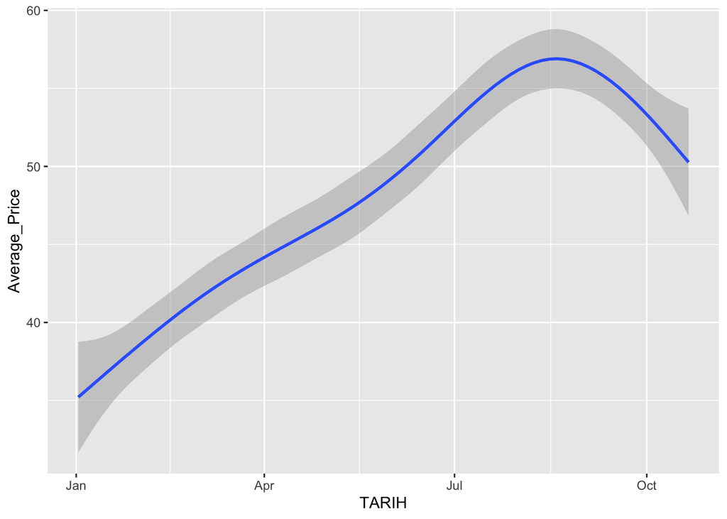

```r
  fishplotsmoothgeneral= ggplot(data=FishPrice, aes(x = TARIH))+
                      geom_smooth(aes(y = Average_Price))

  fishplotsmoothgeneral
```

Most change has been observed in ITHAL(IMPORT)fish prices.

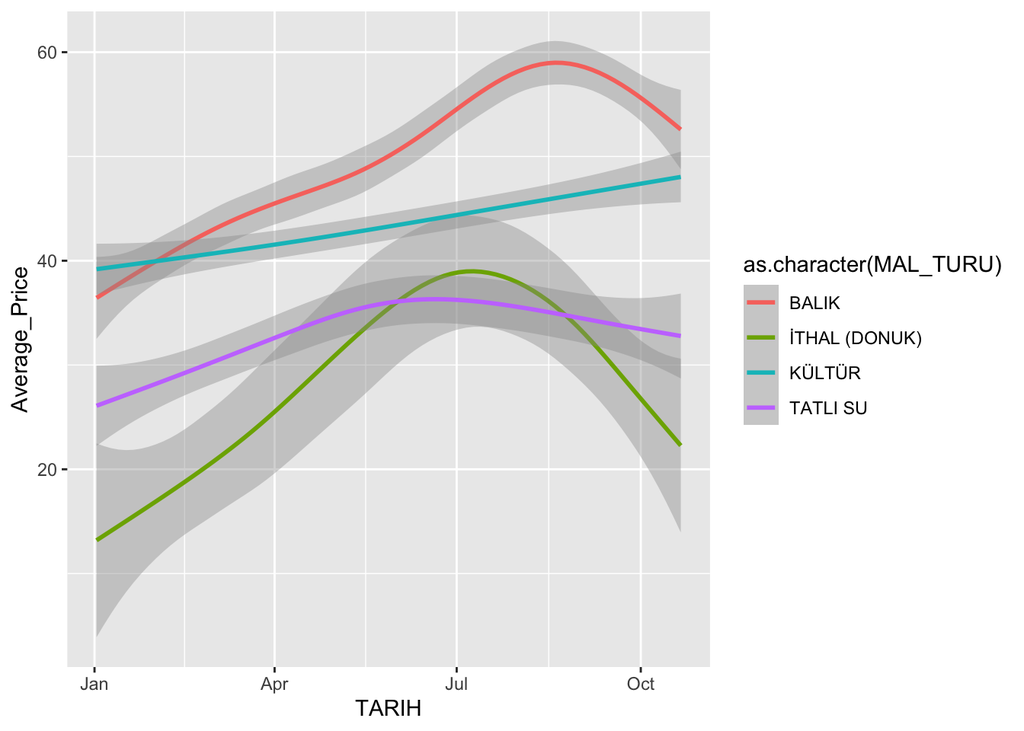

```r
library(ggplot2)

  fishplotsmooth = ggplot(data=FishPrice, aes(x = TARIH))+
                      geom_smooth(aes(y = Average_Price, color=as.character(MAL_TURU)))

  fishplotsmooth
```

When we compare the first month and the last month by average prices. Average prices has been increased approximately %21. But in this perspective we ignore the volume of products.

```r
library(ggplot2)

library(dplyr)

 January<-FishPrice %>%
     filter(TARIH >= ymd_hms("2021-01-01 00:00:00") & TARIH < ymd_hms("2021-01-31 24:00:00"))

   January_Mean<-group_by(January, MAL_ADI)
   January_Means<-summarize(January_Mean,mean(Average_Price))


   October <- FishPrice %>%
     filter(TARIH >= ymd_hms("2021-10-01 00:00:00") & TARIH < ymd_hms("2021-10-31 23:00:00"))

   October_Mean<-group_by(October, MAL_ADI)
   October_Means<-summarize(October_Mean,mean(Average_Price))

compare<-merge(x = January_Means, y = October_Means, by = "MAL_ADI", all.x = TRUE)
   compare$comparetwo<-(compare$`mean(Average_Price).y`/compare$`mean(Average_Price).x`)-1

   summary(compare)
```

```
##    MAL_ADI          mean(Average_Price).x mean(Average_Price).y
##  Length:102         Min.   :  2.00        Min.   :  3.245
##  Class :character   1st Qu.: 11.85        1st Qu.: 12.559
##  Mode  :character   Median : 21.54        Median : 25.234
##                     Mean   : 38.10        Mean   : 50.431
##                     3rd Qu.: 43.72        3rd Qu.: 62.524
##                     Max.   :217.08        Max.   :407.500
##                                           NA's   :10
##    comparetwo
##  Min.   :-0.67597
##  1st Qu.:-0.08808
##  Median : 0.17884
##  Mean   : 0.21297
##  3rd Qu.: 0.45072
##  Max.   : 1.48108
##  NA's   :10
```

While in January prices were increasing, in October prices are decreasing. In below graphs it can be observed easily.

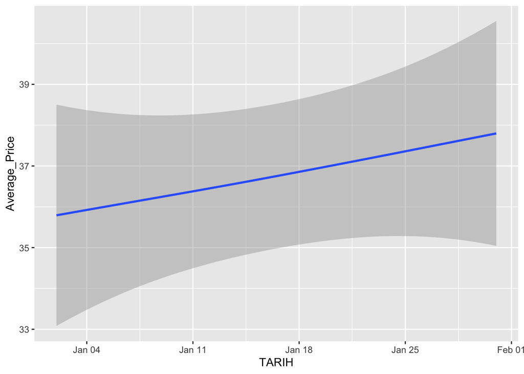

```r
library(ggplot2)

fishplotsmooth2 = ggplot(data=January, aes(x = TARIH))+
                      geom_smooth(aes(y = Average_Price,))
fishplotsmooth2
```

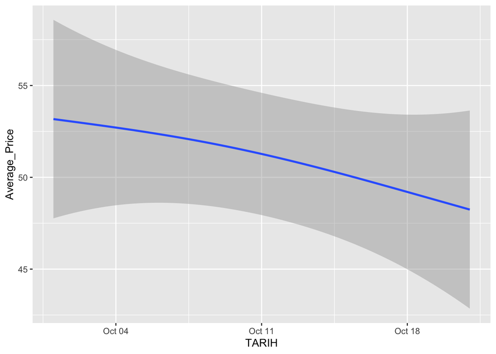

```r
fishplotsmooth3 = ggplot(data=October, aes(x = TARIH))+
                      geom_smooth(aes(y = Average_Price,))

fishplotsmooth3
```

Lastly, it is important to observe that the ratios between fisrt and last months.

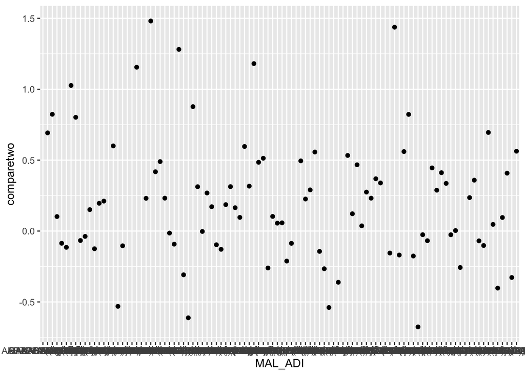

```r
library(dplyr)
library(tidyverse)

 compareplot = ggplot(data=compare, aes(x = MAL_ADI))+
                geom_point(aes(y = comparetwo,))
  compareplot
```